# Multiple sequence alignments, and profile hidden Markov models

[Pablo Vinuesa](https://www.ccg.unam.mx/~vinuesa/), CCG-UNAM, Cuernavaca, México; [@pvinmex](https://twitter.com/pvinmex)

2026-11-09

# 1 About the tutorials

The following tutorials teach how to run [clustalw2](http://www.clustal.org/clustal2/) and [clustal-omega](http://www.clustal.org/omega/) from the command line to generate standard, profile-profile, sequence-profile, and HMM-assisted multiple sequence alignments (MSAs).

It will also demonstrate how to build a **profile hidden Markov models (HMMs)** from an MSA, calibrate, and use it to search for distant homologs with high sensitivity and specificity, with programs from the [HMMER3 suite](http://hmmer.org/).

All exercises will be performed in a Linux environment. Therefore, this tutorial will also introduce some useful [AWK](https://www.gnu.org/software/gawk/manual/gawk.html), [Bash](https://www.gnu.org/savannah-checkouts/gnu/bash/manual/bash.html), and [Perl](https://www.perl.org/) idioms and scripts to analyze the results efficiently from the command line.

## 1.1 ASSUMPTIONS

This tutorial expects that the user has access to a Unix/Linux environment with the standard Bash shell installed, as well as the [clustalw2](http://www.clustal.org/clustal2/), [clustal-omega](http://www.clustal.org/omega/) and [HMMER3](http://hmmer.org/) programs installed, and found in the $PATH. These programs are freely available for download from the clustal.org and [HMMER.org](http://hmmer.org/) servers.

### 1.1.1 RELATED RESOURCES

If you need a thorough introduction or refresher to the Bash shell, including AWK, and Shell scripting, the following extensive tutorial may be helpful: [tutorial avanzado de Linux para Biocómputo](https://github.com/vinuesa/intro2linux), (Spanish)

## 1.2 AUTHOR

These tutorials were designed and written by [Pablo Vinuesa](https://www.ccg.unam.mx/~vinuesa/), CCG-UNAM, Cuernavaca, Mexico ([X - @pvinmex](https://twitter.com/pvinmex)), for the [International Workshops on Bioinformatics, TIB2024](https://www.nnb.unam.mx/tib2024-1/pangenomica-y-filogenomica-microbiana/), my course on comparative genomics taught at the [Bachelor’s Program in Genome Science, LCG-UNAM](https://www.lcg.unam.mx/), and the [Workshop on Genome Sciences, Facultad de Ciencias, UNAM](https://www.ccg.unam.mx/noticias/academicas/taller-de-ciencias-genomicas-de-moleculas-a-ecosistemas/). Although these courses are taught in Spanish, I’ve written this and the other [TIB2024 tutorials available from my GitHub repository](https://github.com/vinuesa/TIB-filoinfo) in English, hoping that they will be helpful to a broader readership.

### 1.2.1 SOURCE REPOSITORY

This and multiple other tutorials are available through the following [TIB-filoinfo GitHub repository](https://github.com/vinuesa/TIB-filoinfo), under the licensing terms provided below.

### 1.2.2 LICENSE

This work is licensed under a [Creative Commons Attribution-NonCommercial 4.0](http://creativecommons.org/licenses/by-nc/4.0/)

# 2 Multiple sequence alignment (MSA) using the CLUSTAL family of programs

[figure not shown]

Clustal.org Webpage.

[Multiple sequence alignments (MSAs)](https://en.wikipedia.org/wiki/Multiple_sequence_alignment) are essential in most bioinformatics analyses that involve comparing homologous sequences. The exact or exhaustive approach to computing an optimal alignment has a computational complexity of $O(L^N)$ for $N$ sequences of length $L$, making it prohibitive for even small numbers of sequences [(Sievers et al. 2011)](https://www.embopress.org/doi/full/10.1038/msb.2011.75). Therefore, all MSA algorithms implement some sort of heuristics [(see Katho K. ed. 2021)](https://link.springer.com/book/10.1007/978-1-0716-1036-7), such as the *progressive multiple sequence alignment algorithm* first implemented in the the popular [Clustal](http://www.clustal.org/) family programs.

Clustal programs are used for multiple sequence alignment of DNA and protein sequences. The software and its algorithms have gone through several iterations, with $Clustal{\Omega}$ (Omega) being the latest version, published in of 2011 [(Sievers et al. 2011)](https://www.embopress.org/doi/full/10.1038/msb.2011.75). It is available as standalone software, via a web interface, and through a [Web server hosted by the European Bioinformatics Institute](https://www.ebi.ac.uk/jdispatcher/msa/clustalo).

Clustal has been an important bioinformatic software, with two of its academic publications ranking among the top 100 most cited papers of all time.

Here we will demonstrate the use of the current command-line versions: [**clustalw2/clustalX**](http://www.clustal.org/clustal2/) and [**clustal-omega**](http://www.clustal.org/omega/) to perform:

1. Standard multiple sequence alignments of protein sequences
2. Profile to profile (p2p), and sequence to profile (s2p) alignments
3. Build CDS alignments guided by the alignment of the the corresponding translation products (proteins)
4. Use a profile hidden Markov model to guide the alignment of protein sequences using $clustal-omega$

Both $Clustalw2$ and $Clustal{\Omega}$ can read multiple sequence formats, including CLUSTAL and FASTA, and write the computed alignments in even more formats, including STOCKHOLM, NEXUS, and PHYLIP.

# 3 PRELIMINARIES - setting up your working directory

The following code snippets will set up the working directory for the tutorials, and fetch or generate symbolic links to the required sequences and scripts.

```bash
# i) Change directory into your working directory and make the following new directory to hold the sequence data for the exercises
if [ ! -d sesion3_clustal_y_hmmer ]; then
    mkdir sesion3_clustal_y_hmmer && cd sesion3_clustal_y_hmmer
else
   cd sesion3_clustal_y_hmmer
fi

# ii) use wget on the command line to fetch the required files from my TIB-filoinfo GitHub repo
wget -c https://github.com/vinuesa/TIB-filoinfo/raw/master/docs/sesion4_alineamientos/sequences_for_alingment.tgz

if [ -s sequences_for_alingment.tgz ]
then
     if file sequences_for_alingment.tgz | grep gzip &> /dev/null
     then
         echo "unpacking sequences_for_aligment.tgz ..."
         tar -xzf sequences_for_alingment.tgz
     else
         echo "ERROR: This is not a gzip file"
     fi
else
    echo "ERROR: sequences_for_aligment.tgz not found"
fi

# iii) Download the required scripts to your ~/bin directory
base_url=https://raw.githubusercontent.com/vinuesa/TIB-filoinfo/refs/heads/master

if [ -d ~/bin ]; then
    cd ~/bin
else
    mkdir ~/bin && cd ~/bin
fi

# This is a Bash array holding the list of scripts to be downloaded
scripts=(col_sumStats.sh split_fasta.pl translate_fastas.pl prot2cdnAln.pl convert_aln_format_batch_bp.pl fasta_toolkit.awk extract_N-or_C-terminal_regions_and_compute_counts.pl select_sequences_by_ID.pl)

# Iterate over the array elements, fetching each script with 'wget -c' and making them executable with 'chmod 755'
for f in "${scripts[@]}"
do
    wget -c "$base_url"/"$f"
    [ -s "$f" ] && chmod 755 "$f"
done

# Change directory back to the previous working directory
cd -

# list the directory contents
pwd && ls

# make a symlink to the Human_Ras_Superfam_proteins_Wennerberg_JCS05.faa sequences and Ras_fam_PF00071.hmm
ln -s /export/space3/users/vinuesa/DBs/sequences/Human_Ras_Superfam_proteins_Wennerberg_JCS05.faa .
ln -s /export/space3/users/vinuesa/DBs/Pfam/Ras_fam_PF00071.hmm .
```

We are ready to start the hands-on tutorials on running **clustal** and **hmmer** from the command line.

# 4 Clustalw: background and exercises

[Clustalw](http://www.clustal.org/clustal2/) implements a fast version of the **progressive multiple sequence alignment algorithm** (sketched below), featuring a fast and simple method for making “**guide trees**.” These are computed using fast clustering methods (UPGMA or NJ) of a distance matrix, which is calculated from the sequences using either exhaustive (dynamic programming) or heuristic (*k*-mer distances) methods.

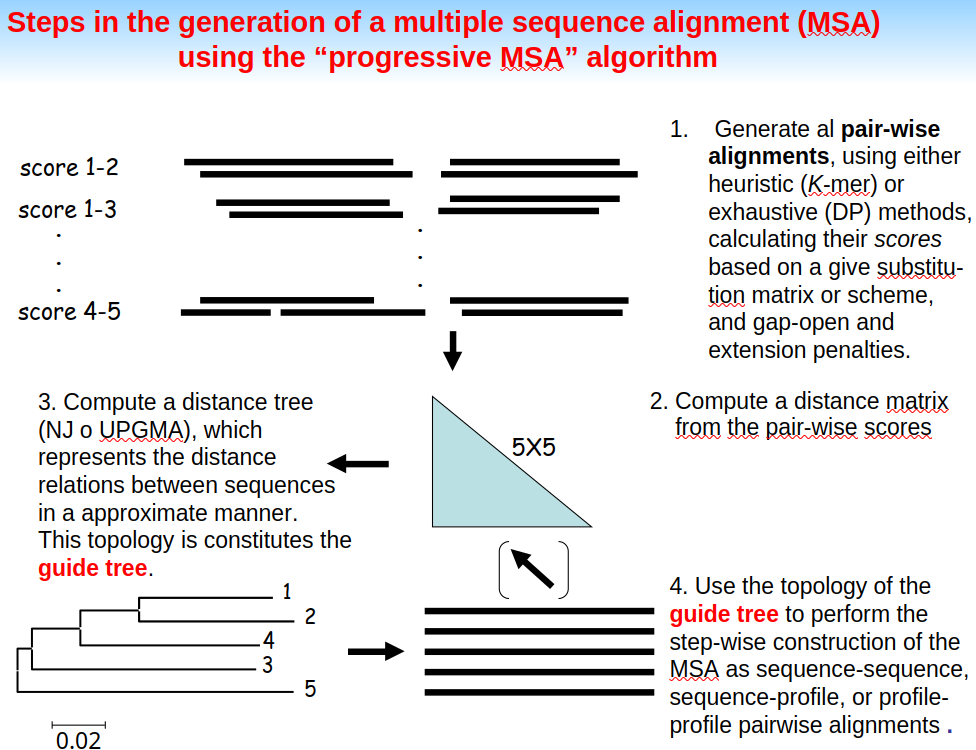

Schematic representation of the **progressive MSA algorithm**.

The resulting **guide trees are used to define the order of alignment during the later progressive alignment phase**. The general idea is to start with alignments of just two sequences, usually the closest ones in the data set. The alignment is then built up by aligning sequences to sequences (s-s), alignments (**profiles**) with each other (p2p alignments), or sequences to alignments (s2p), according to the topology of the guide tree.

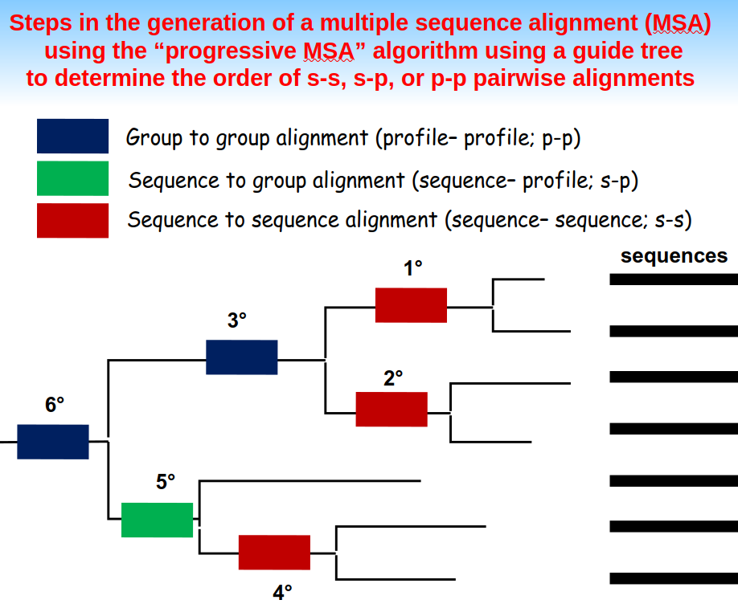

**Definng the order of pair-wise s-s, s-p, and p-p alignments** used by the progressive MSA construction algorithm with the aid of a **guide tree**.

Clustalw can be freely obtained from the [Clustalw2 webpage](http://www.clustal.org/clustal2/). [Clustal 2](http://www.clustal.org/clustal2/) comes in two flavors: the **command-line version Clustal W**, and the **graphical version Clustal X**. Precompiled executables for Linux, Mac OS X, and Windows are available.

[figure not shown]

Clustalw2 Webpage.

## 4.1 Basic Clustalw2 command-line options

Here we are going to use only the command-line version Clustalw.

Note that:

- the $clustalw$ and $clustalw2$ calls are equivalent, and execute the same clustalw version 2.1 binary
- the alignment algorithms in $Clustalw$ and $Clustalx$ are exactly the same
- only $Clustalx$ has a graphical user interface

Below is a compilation of some of the most frequently used $clustalw$ command-line options:

```
#======================================================================================
# Basic clustalw usage and options
#--------------------------------------------------------------------------------------

# explore the manuals
man clustalw

clustalw -help
clustalw -fullhelp

# minimal clustal command line call
clustalw -infile=fasta_no_alineado -outfile=archivo_cluwaln.afa

# clustalw call with modified parameters
clustalw -infile=archivo.fasta -align -pwmatrix=blosum -pwgapopen=12
-pwgapext=0.2 -matrix=blosum -gapopen=12 -gapext=0.2 -outorder=aligned
-convert -outfile=archivo_aln1.phy -output=<(phylip|clustal|fasta|nexus)>
```

## 4.2 Standard and customized clustalw alignment of prokaryotic and eukaryotic GDP (Glycerol-3-phosphate dehydrogenase [NAD(+)], cytoplasmic) protein sequences: the impact of alignment parameters

The next lines show how to align the the provided FASTA files with GDP sequences from prokaryotes and eukaryotes, writing the resulting multiple sequence alignments (MSAs) in FASTA or Clustal formats.

```bash
# 1. default clustalw alignments
clustalw -infile=4_GDP_procar_ualn.faa -outfile=4_GDP_procar_cluAln.faa -output=fasta
clustalw -infile=6_GDP_eucar_ualn.faa -outfile=6_GDP_eucar_cluAln.faa -output=fasta

# 2. This clustalw call uses ~ 10% higher gap-open and gap extension penalties, both for the pairwise and multiple sequence alignment blocks
clustalw -infile=6_GDP_eucar_ualn.faa -outfile=6_GDP_eucar_cluAln2.aln -output=clustal -pwgapopen=13 -pwgapext=0.22 -gapopen=13 -gapext=0.22
```

## 4.3 Profile-profile alignment with clustalw, and writing output in Clustal’s native clustal format

```bash
# 1. compute a profile to profile alignment of the default alignments
clustalw -profile -profile1=6_GDP_eucar_cluAln.faa -profile2=4_GDP_procar_cluAln.faa -outfile=10_GDP_eucar_prokar_prof2prof.aln -output=clustal

# 2. compute a profile to profile alignment using the eukaryotic 6_GDP_eucar_cluAln2.aln alignment
clustalw -profile -profile1=6_GDP_eucar_cluAln2.aln -profile2=4_GDP_procar_cluAln.faa -outfile=10_GDP_eucar_prokar_prof2prof2.aln -output=clustal
```

### 4.3.1 The clustal format

The **Clustal format** can be conveniently visualized directly in the terminal.

The following command will allow us to compare the N-terminal regions of both profile alignments.

```bash
# display the 10_GDP_eucar_prokar.aln MSA written in clustal format
head -15 10_GDP_eucar_prokar_prof2prof.aln 10_GDP_eucar_prokar_prof2prof2.aln
```

```
==> 10_GDP_eucar_prokar_prof2prof.aln <==
CLUSTAL 2.1 multiple sequence alignment


gpdhuman        ---------------MASKK----------------VCIVGSGNWGSAIAKIVGGNAAQL
gpdarabit       ----------------AGKK----------------VCIVGSGDWGSAIAKIVGGNAAQL
gpdamouse       ----------------AGKK----------------VCIVGSGNWGSAIAKIVGSNAGRL
gpdadrome       ---------------MADKVN---------------VCIVGSGNWGSAIAKIVGANAAAL
gpdacaeel       ---------------MSPKK----------------VTIIGSGNWGSAIARIVGSTTKSF
gpd1yeast       MSAAADRLNLTSGHLNAGRKRSSSSVSLKAAEKPFKVTVIGSGNWGTTIAKVVAENCKGY
gpdaecoli       -------------MNQRNAS----------------MTVIGAGSYGTALAITLARNGHEV
gpdahaein       -------------MITSQTP----------------ITVLGAGSYGTALAITFSRNGSPT
gpdpseu         -----------------------------------------MTSCCGAVAKTRWRN----
gpdabacsu       -----------------MKK----------------VTMLGAGSWGTALALVLTDNGNEV
                                                           .   ::*     .

==> 10_GDP_eucar_prokar_prof2prof2.aln <==
CLUSTAL 2.1 multiple sequence alignment

gpdhuman        -------------------------------MASKKVCIVGSGNWGSAIAKIVGGNAAQL
gpdarabit       --------------------------------AGKKVCIVGSGDWGSAIAKIVGGNAAQL
gpdamouse       --------------------------------AGKKVCIVGSGNWGSAIAKIVGSNAGRL
gpdadrome       ------------------------------MADKVNVCIVGSGNWGSAIAKIVGANAAAL
gpdacaeel       -------------------------------MSPKKVTIIGSGNWGSAIARIVGSTTKSF
gpd1yeast       MSAAADRLNLTSGHLNAGRKRSSSSVSLKAAEKPFKVTVIGSGNWGTTIAKVVAENCKGY
gpdaecoli       -----------------------------MNQRNASMTVIGAGSYGTALAITLARNGHEV
gpdahaein       -----------------------------MITSQTPITVLGAGSYGTALAITFSRNGSPT
gpdpseu         -----------------------------------------MTSCCGAVAKTRWRN----
gpdabacsu       ---------------------------------MKKVTMLGAGSWGTALALVLTDNGNEV
                                                           .   ::*     .
... TRUNCATED


Note that clustal uses the following symbols below each alignment block to highlight conserved residues:
*   (asterisk)  positions that have a single and fully conserved residue
:   (colon)     conserved: conservation between groups of strongly similar properties (score > 0.5 on the PAM 250 matrix)
.   (period)    semi-conserved: conservation between groups of weakly similar properties (score ≤ 0.5 on the PAM 250 matrix)
    (blank)     non-conserved
```

Notice the long N-terminal extension of the yeast sequence.

What do you think about the two MSAs, which one do you think is more likely correct, and why?

### 4.3.2 Using seaview to visualize and edit MSAs

[Seaview](https://doua.prabi.fr/software/seaview) is a multi-platform, graphical user interface for multiple sequence alignment and molecular phylogeny.

- Seaview reads and writes various file formats (NEXUS, MSF, CLUSTAL, FASTA, PHYLIP, MASE, Newick) of DNA and protein sequences and of phylogenetic trees.
- Seaview drives programs muscle or Clustal Omega for multiple sequence alignment, and also allows to use any external alignment algorithm able to read and write FASTA-formatted files.
- Seaview drives the Gblocks program to select blocks of evolutionarily conserved sites.
- Seaview computes phylogenetic trees by
  - parsimony, using PHYLIP’s dnapars/protpars algorithm,
  - distance, with NJ or BioNJ algorithms on a variety of evolutionary distances,
  - maximum likelihood, driving program PhyML 3.1.
- Seaview can use the Transfer Bootstrap Expectation method to compute the bootstrap support of PhyML and distance trees.
- Seaview uses the Treerecs method to reconcile gene and species trees.
- SeaView prints and draws phylogenetic trees on screen, SVG, PDF or PostScript files.
- SeaView allows to download sequences from EMBL/GenBank/UniProt using the Internet.

Seaview can be run from the command line, and the options can be found with:

```bash
# display the help menu
seaview -h
```

or here: [seaview command manual](https://doua.prabi.fr/software/seaview_data/seaview#Program%20arguments)

To visualize an alignment, simply call $seaview$ with the alignment file name as single argument on the command line:

```bash
seaview 10_GDP_eucar_prokar_prof2prof2.aln &
```

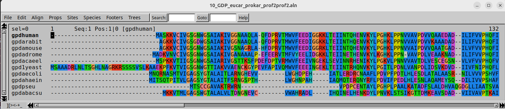

Visualization of an MSA with seaview.

## 4.4 Multiple sequence alignment of protein-coding sequences (CDSs)

We will first attempt to perform a default MSA of nine full-length *leuA* sequences from diverse *Bacillales* using $clustalw$

Lets firs count the sequences, and have a look at them

```bash
# count sequences
grep -c '^>' leuA-Bacillales.fas

# display file
cat leuA-Bacillales.fas
```

```
9
>B_anthracis_Ames 30261500
atgaagcaaattttgttcatggatacgacgctacgtgatggcgaacaatcaccaggagtaaatttaaatgaacaagagaa
attgcaaattgcaaggcaattagagagactagggattcatgtcatggaagctggctttgcagcagcttccgaaggggatt
ttcaatcggtaaagcgcatcgcaaatacaattcaaaatgctacagttatgagtttagcaagagcgaaagaaagtgatatt
cgaagagcatatgaagctgtgaaaggtgcggtatctcctcgtttacacgtatttttagctacgagtgatattcatatgaa
gtataaactttgtatgtcaaaagaagatgtattagatagtatttatcgatcggttacacttgggaaatcgttatttccga
cagtacaattttcagcagaagatgcaacaagaacagcaagagattttttagctgaagcggtagaagttgcgattcgtgca
ggagcgaatgtaattaatattccagatacagttgggtatacgaatccagaagaatattatgctctttttaaatatttaca
agaatccgttccttcatatgaaaaagcaattttctcttgtcattgtcatgatgatcttgggatggcggtagcaaattcat
tagctgcagttgaaggcggagcgttgcaagtagaaggaacaattaatgggattggagaaagagcagggaatgcggcgtta
gaagaggttgcagttgctcttcatattaggaaagatttctataaagcagagccttctatgacgctaaaagaaattaaagc
gacaagtacattagtaagcagattaacgggtatggttgtatcgaaaaataaagcgattgttggagcaaatgcattcgctc
atgaatcaggcattcatcaagatggtgtattaaaagaagtgacaacatatgaaattattgaaccagcgctagtaggcgaa
tctcaaaatctatttgtacttggaaaacattctgggcgtcacgcgtttacagaaaaaatgaaagaacttggctatgaatt
tacaaacgacgagcgggatgcagtatttgaagcatttaaaaaattagctgatcgtaagaaggaaattactgaggaagatt
tacgagcacttatgcttggtgaagcagcatttgcggctcagcaatataacattacgcaattgcaagtacatttcgtatca
aatagtacacaatgtgcgacagttgtactaaaagatgaggaaggaaatgtattcgaagatgcagctactggctctggtag
tattgaagcgatttataatgcaatccaaagaattttaggattggaatgtgaattggcggattatcgcatacaatctatta
cacaaggtcaagatgcactggctcatgttcatgttgaattaaaagaaggagcacatcaagtatcaggttttggtgttgca
caagacgtattggaagcgtcggcaagagcatatgtccacgcagcggggaaattgaaatcttttatccagcttgtgaaata
a
... truncated
```

Do you think the sequence shown above might be a complete CDS? Why?

### 4.4.1 Default alignment of CDSs (the incorrect way of doing it!)

Align the *leuA* sequences under default parameters:

```bash
# generate the MSA
clustalw -infile=leuA-Bacillales.fas -outfile=leuA-Bacillales.aln

# display the MSA
cat leuA-Bacillales.aln
```

```
... truncated
B_anthracis_Ames                TGTTGAATTAAAAGAA--GGA-GCACATCAAGTATCAGGTTTTGGTGTTG
B_thuringiensis_konkukian       TGTTGAATTAAAAGAA--GGA-GCACATCAAGTATCAGGTTTTGGTGTTG
B_cereus_ATCC14579              TGTTGAATTAAAAGAA--GGT-AGTCACCAAATATCAGGTTTCGGAGTTG
B_licheniformis_ATCC_14580      CGTCAGGGTG-ATGAT--CGATGGAAAAGAATCGGGAGGACGCGGGGTTG
B_subtilis                      TGTAAGAGTT-TTGGT--GAACGGAAAAGAATCAGCAGGGCGGGGCATAG
B_halodurans                    TGTTCAAATGGATTAT--CAA-GGAGTCGTCTCAAGTGGACGCGGCACGG
O_iheyensis                     TGTTCAAATT-ATTAT--TAATGGAGAAACAATCAATGGTAGAGGGTCTG
L_innocua                       TGTCGTCATTAAAGATGATAATGGCACTGAATTCCATGGTATCGGTATCG
L_monocytogenes_4b_F2365        TGTCGTCATTAAAAATGACAAAGGCGCTGTGTTCCATGGTATCGGTATTG
                                 **     *                            **    **    *

B_anthracis_Ames                CACAAGACGTATTGGAAGCGTCGGCAAGAGCATATGTCCACGCAGCGGGG
B_thuringiensis_konkukian       CACAAGACGTATTGGAAGCGTCGGCAAGAGCATATGTCCACGCAGCGGGG
B_cereus_ATCC14579              CGCAAGACGTATTGGAAGCGTCGGCGAGAGCTTATGTCCATGCAGCAGGG
B_licheniformis_ATCC_14580      CCCAGGATGTTCTCGAAGCATCTGCCAAAGCCTACTTGAATGCTGTGAAC
B_subtilis                      CGCAAGACGTATTAGAAGCATCAGCGAAAGCCTATTTGAACGCAGTAAAC
B_halodurans                    CCCATGATGTGTTAGAAGCGTCAGCAAAAGCCTATTTAAACGCAGTTAAT
O_iheyensis                     CTCAGGATGTGCTTCAAGCGTCTGCAGTAGCATTCATTCAGGCAGTAAAT
L_innocua                       ATTTTGATGTTTTAACAGCTAGTGCTAAAGCTTATTTGCAAGCATCTGGA
L_monocytogenes_4b_F2365        ATTTTGACGTTTTAACTGCTAGTGCTAAAGCTTATTTGCAAGCATCAGGC
                                     ** **  *    **    **   *** *   *  * **

B_anthracis_Ames                AAATTGAAATCTTTTATCCAGCTTGTGAAATAA-----------------
B_thuringiensis_konkukian       AAATTGAAATCTTTTATCCAGCTTGTGAAATAA-----------------
B_cereus_ATCC14579              AAATTAAAATCTCTTATAGCGCTTGTGAAATAA-----------------
B_licheniformis_ATCC_14580      CGCTATCTCGTATTGAAGACGAATACGGAAGGATTGTCAAAACAGGCGGC
B_subtilis                      CGTCAATTGGTTTTCCAGTCGAATATGAGCGGATTGAAAAACCACACAGC
B_halodurans                    CG--AACGATTAATCGAAAGAAATATGCAGAAGTTTATGGATCGAA----
O_iheyensis                     CGTTATTACGT--TCAAAAGAAA-----GCAAATC--TAACTCGACTTGT
L_innocua                       AAAAGCAAATCTACAAGTAAGCA----AGCTGATTTCGAGGAGGTAAAGT
L_monocytogenes_4b_F2365        AAAAGCAAAACCGCCAGTAAGCA----AGCTGATTTCGAGGAGGTAAAAT
... truncated
```

Carefully scrutinize the MSA shown above. What do you think about the alignment’s quality? Provide your comments.

### 4.4.2 The correct way of aligning CDSs

The correct way of aligning CDSs requires their translation, and alignment at the protein level, as shown in the following figure:

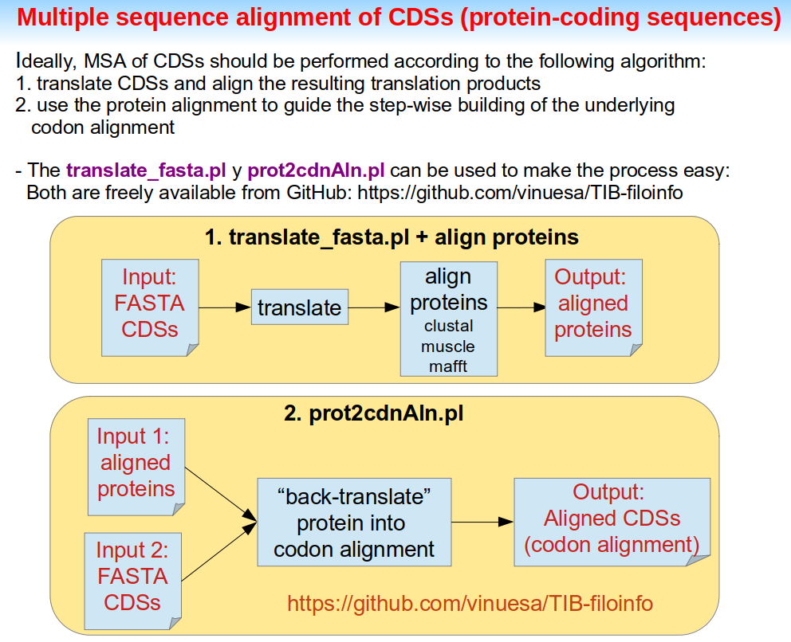

Strategy to peform CDS alignments correctly.

#### 4.4.2.1 Tranlate CDSs to proteins with the aid of translate_fastas.pl

Here we assume that all CDSs in the FASTA file are in the same +1 frame.

```bash
translate_fastas.pl -e fas -t 11
```

Lets visualize the translated products:

```bash
cat leuA-Bacillales_translated.faa
```

```
>B_anthracis_Ames 30261500
MKQILFMDTTLRDGEQSPGVNLNEQEKLQIARQLERLGIHVMEAGFAAASEGDFQSVKRI
ANTIQNATVMSLARAKESDIRRAYEAVKGAVSPRLHVFLATSDIHMKYKLCMSKEDVLDS
IYRSVTLGKSLFPTVQFSAEDATRTARDFLAEAVEVAIRAGANVINIPDTVGYTNPEEYY
ALFKYLQESVPSYEKAIFSCHCHDDLGMAVANSLAAVEGGALQVEGTINGIGERAGNAAL
EEVAVALHIRKDFYKAEPSMTLKEIKATSTLVSRLTGMVVSKNKAIVGANAFAHESGIHQ
DGVLKEVTTYEIIEPALVGESQNLFVLGKHSGRHAFTEKMKELGYEFTNDERDAVFEAFK
KLADRKKEITEEDLRALMLGEAAFAAQQYNITQLQVHFVSNSTQCATVVLKDEEGNVFED
AATGSGSIEAIYNAIQRILGLECELADYRIQSITQGQDALAHVHVELKEGAHQVSGFGVA
QDVLEASARAYVHAAGKLKSFIQLVK*
>B_cereus_ATCC14579 30019549
LFMDTTLRDGEQSPGVNLNEQEKLQIARQLERLGIHVMEAGFAAASEGDFQSVKRIANTI
QNATVMSLARAKESDIRRAYEAVKGAVSPRLHVFLATSDIHMKYKLCMSKEDVLNSIHRS
VTLGKSLFPTVQFSAEDATRTSRAFLAEAVEIAIRAGANVINIPDTVGYTNPEEYYSLFE
YLQESVPSYEKAIFSCHCHDDLGMAVANSLAAVEGGALQVEGTINGIGERAGNAALEEVA
VALHIRKDFYKAEPSMTLKEIKATSILVSRLTGMVVPKNKAIVGANAFAHESGIHQDGVL
KEVTTYEIIEPALIGESQNLFVLGKHSGRHAFTEKMKELGYEFTNEERDAAFEAFKKLAD
RKKEITEEDLRALMLGEAAFAAQQYNITQLQVHFVSNSTQCATVVLKDEEGNVYEDAATG
SGSIEAIYNAIQRILGLECELADYRIQSITQGQDALAHVHVELKEGSHQISGFGVAQDVL
EASARAYVHAAGKLKSLIALVK*
... truncated
```

Note that the **stop codons** were translated as ’*’ symbols. These are not amino acids, and should be removed. This can be easily achieved with a simple $sed$ one-liner:

```bash
# use sed to replace the terminal * symbols by nothing
sed 's/\*$//' leuA-Bacillales_translated.faa > k && mv k leuA-Bacillales_translated.faa
```

```bash
# visualize the edited translation products
cat leuA-Bacillales_translated.faa
```

```
>B_anthracis_Ames 30261500
MKQILFMDTTLRDGEQSPGVNLNEQEKLQIARQLERLGIHVMEAGFAAASEGDFQSVKRI
ANTIQNATVMSLARAKESDIRRAYEAVKGAVSPRLHVFLATSDIHMKYKLCMSKEDVLDS
IYRSVTLGKSLFPTVQFSAEDATRTARDFLAEAVEVAIRAGANVINIPDTVGYTNPEEYY
ALFKYLQESVPSYEKAIFSCHCHDDLGMAVANSLAAVEGGALQVEGTINGIGERAGNAAL
EEVAVALHIRKDFYKAEPSMTLKEIKATSTLVSRLTGMVVSKNKAIVGANAFAHESGIHQ
DGVLKEVTTYEIIEPALVGESQNLFVLGKHSGRHAFTEKMKELGYEFTNDERDAVFEAFK
KLADRKKEITEEDLRALMLGEAAFAAQQYNITQLQVHFVSNSTQCATVVLKDEEGNVFED
AATGSGSIEAIYNAIQRILGLECELADYRIQSITQGQDALAHVHVELKEGAHQVSGFGVA
QDVLEASARAYVHAAGKLKSFIQLVK
... truncated
```

#### 4.4.2.2 Align the translated products keeping the original input order in the output MSA

Note that it is critical to **conserve the original ordering of the sequences** from the input file in the output MSA using the $-OUTORDER=input$ option.

```bash
# print clustalw help
clustalw -help

# run clustalw
clustalw -infile=leuA-Bacillales_translated.faa -outfile=leuA-Bacillales_translated_clu.faa -output=fasta -OUTORDER=input
```

#### 4.4.2.3 Use the prot2cdnAln.pl Perl script to reconstruct the CDS MSA using the translation product MSA as guide alignment.

```bash
# print the script's help to STDOUT
prot2cdnAln.pl -h

# run the script
prot2cdnAln.pl leuA-Bacillales.fas leuA-Bacillales_translated_clu.faa
```

#### 4.4.2.4 Compare the leuA-Bacillales_cdnaln.fas codon alignment with the default leuA-Bacillales.aln MSA

Display both the correct codon and default MSAs of the *leuA* CDSs:

```bash
# this one is the correct codon/CDS alignment
seaview leuA-Bacillales_cdnaln.fas &

# this one is the default, incorrect codon/CDS alignment
seaview leuA-Bacillales.aln &
```

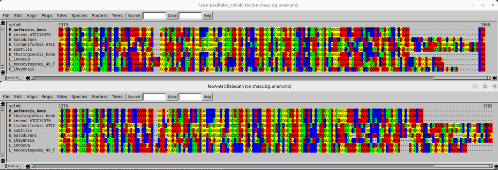

Comparison of the codon and default MSAs of the *leuA* CDSs.

The output shown above clearly demonstrates that when aligning CDSs, we should first translate them to proteins, perform the alignment of the translation products, and finally reconstitute the CDS alignment using the protein MSA as a guide or template.

# 5 Multiple sequence alignment with clustal${\Omega}$

Clustal${\Omega}$ is the last incarnation of the Clustal family of MSA programs. It offers a significant increase in scalability over previous versions thanks to the implementation of novel algorithms that avoid bottlenecks of the classic progressive multiple sequence alignment algorithms (Sievers et al. 2011).

## 5.1 What are the differences between Clustalw and Clustal-omega?

Clustalw, and earlier Culstal versions, use fast word-based alignments (*k*-mers) for these comparisons, which made it memory efficient and fast enough to work on personal computers. However, as the number of sequences grows above a few thousand, the $O(N^2)$ complexity associated with the computation of pairwise distance matrices to generate “guide trees” becomes very time consuming.

- $Clustal\Omega$ implements an $O(NlogN)$ method called **$mBed$** (Sievers et al. 2011) that **allows guide trees of hundreds of thousands of sequences to be computed** by restricting the calculation of sequence alignment scores to NLog(N). This is the main algorithmic improvement providing Clustal Omega with the capacity and scalability required for current genomic data sets.
- The second main development in $Clustal\Omega$ was the replacement of the conventional dynamic programming, and profile alignment, with an **alignment engine provided by $HHalign$ capable of aligning profile hidden Markov models (HMMs)**. HMM-HMM alignments had been shown to have very high accuracy for profile HMM alignment [(Söding 2005)](https://academic.oup.com/bioinformatics/article/21/7/951/268976?login=true). The use of $HHalign$ provides $Clustal\Omega$ with greatly increased accuracy when compared to earlier Clustal programs, as measured on structure based alignment benchmarks.

This is the paper describing Clustal${\Omega}$, along with its abstract: Sievers et al. 2011. Fast, scalable generation of high-quality protein multiple sequence alignments using Clustal Omega. [Mol Syst Biol. 2011 Oct 11:7:539. doi: 10.1038/msb.2011.75](https://www.embopress.org/doi/full/10.1038/msb.2011.75)

**ABSTRACT** Multiple sequence alignments are fundamental to many sequence analysis methods. Most alignments are computed using the progressive alignment heuristic. These methods are starting to become a bottleneck in some analysis pipelines when faced with data sets of the size of many thousands of sequences. Some methods allow computation of larger data sets while sacrificing quality, and others produce high-quality alignments, but scale badly with the number of sequences. In this paper, we describe a new program called Clustal Omega, which can align virtually any number of protein sequences quickly and that delivers accurate alignments. The accuracy of the package on smaller test cases is similar to that of the high-quality aligners. On larger data sets, Clustal Omega outperforms other packages in terms of execution time and quality. Clustal Omega also has powerful features for adding sequences to and exploiting information in existing alignments, making use of the vast amount of precomputed information in public databases like Pfam.

[figure not shown]

The $Clustal\Omega$ Webpage.

## 5.2 Default alignment of multiple FASTA files with clustal-omega using a for loop

We will repeat the MSA of the two FASTA files containing four bacterial and six eukaryotic GDP protein sequences using $clustalo$, called from a Bash $for$ loop to align all *ualn.faa files found in the current directory.

```bash
# call clustalo within a for loop to align all *ualn.faa files found in the working directory
for file in *ualn.faa; do clustalo -i $file -o ${file%.*}_cluOaln.phy --outfmt phy --output-order input-order --threads 4; done
```

## 5.3 Profile to profile (p2p) alignment

This $clustalo$ call performs a profile-profile alignment of the two input alignments.

```bash
clustalo --profile1 4_GDP_procar_ualn_cluOaln.phy --profile2 6_GDP_eucar_ualn_cluOaln.phy --infmt phy --outfmt clu -o 10_GDP_eucar_prokar_cluOp2p.aln --threads 4
```

## 5.4 Sequences to profile (s2p) alignment

This $clustalo$ call performs a sequence (4_GDP_procar_ualn.faa) to profile (6_GDP_eucar_ualn_cluOaln.phy) alignment.

```bash
clustalo --profile1 6_GDP_eucar_ualn_cluOaln.phy -i 4_GDP_procar_ualn.faa -o 10_GDP_eucar_prokar_cluOs2p.aln --outfmt clu --threads 4
```

## 5.5 Comparison of the p2p and s2p 10_GDP_eucar_proka alignments

The $paste$ command allows us to conveniently display the two MSAs side by side for their comparision.

```bash
paste 10_GDP_eucar_prokar_cluOp2p.aln 10_GDP_eucar_prokar_cluOs2p.aln
```

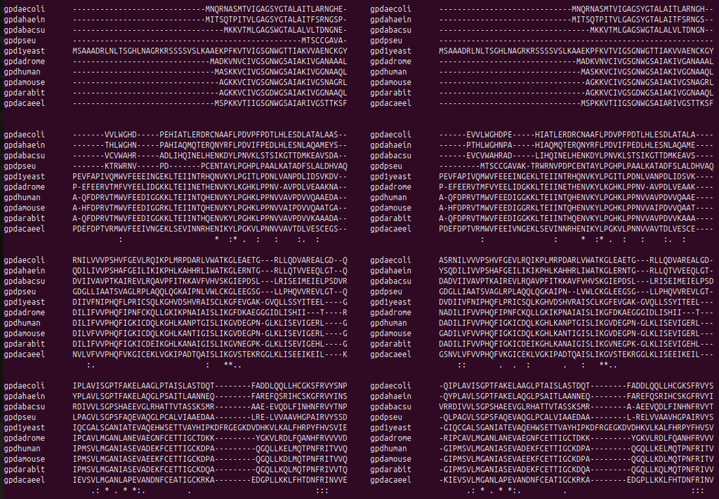

Pasted $Clustal\Omega$ p2p vs. s2p GDP alignments in clustal format.

A few differences can be seen towards the end of the p2p and s2p GDP alignments shown above. Which one do you think is the best?

To gain evidence in favor for one or the other, we will perform a new $clustalo$ alignment on the full 10 GDP sequence set using *iterations* and *Kimura* correction.

## 5.6 Alignment of the 10 GDP sequences with clustal-omega using iterations and Kimura correction

Iterations can be used in an attempt to improve the alignment by a process of repeated refinement (Sievers & Higgins, 2014).

Iterative refinement can be accomplished in two ways:

1. **guide-tree refinement** and/or
2. refinement using the multiple alignment output as an **external profile HMM**.

This process is illustrated in the bottom part of Figure shown below (Sievers & Higgins, 2014).

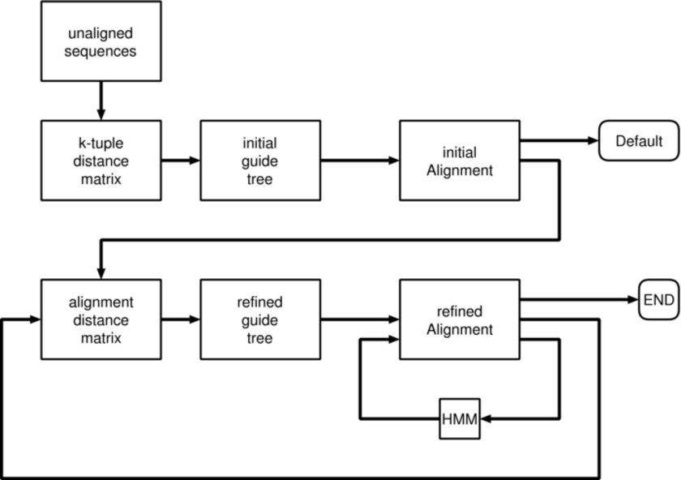

[$Clustal\Omega$ default and iteration algorithm steps.](https://currentprotocols.onlinelibrary.wiley.com/cms/asset/579aaae7-5f6b-4e60-8cb5-5e8f032baa53/cpbi0313-fig-0001-m.jpg)

The second iteration scheme uses a **profile HMM**, derived from an alignment of the input sequences, as an external profile. The first alignment gives an outline of the positions where residues are more likely to align in a second alignment round.

Both iteration methods can be carried out a number of times, separately or in combination. The default is to combine them, as will be shown in the protocol below.

```bash
# 1. combine the source FASTA files into a single one named 10_GDP_procar_eukar_ualn.fas
cat 4_GDP_procar_ualn.faa 6_GDP_eucar_ualn.faa > 10_GDP_procar_eukar_ualn.fas

# 2. Perform clustalo MSA with two iterations and using Kimura-corrected distances
clustalo -i 10_GDP_procar_eukar_ualn.fas --iter 2 --use-kimura -o 10_GDP_eucar_prokar_cluoAln2iter.aln --outfmt clu --threads 4
```

Clustal Omega will first construct a guide tree and align the sequences in the order specified by the guide tree. This alignment is then used in two ways:

1. A new guide tree is constructed, based on distances derived from the aligned sequences
2. The alignment is converted into a profile HMM

During the second round of alignment (the first iteration), sequences are aligned to the internally constructed profile HMM, pseudo-count information is transferred to the unaligned sequences, and the ‘enhanced’ sequences are aligned to each other in the order specified by the newly constructed guide tree. The final alignment is written in *clustal* format to 10_GDP_eucar_prokar_cluoAln2iter.aln .

The first iteration will be followed by another guide-tree construction and HMM pseudo-count transfer.

While the alignment accuracy is expected to be higher for the iterated alignments, so is also the response time. Every round of iteration can take up to three times longer than the initial alignment. For example, if the initial alignment took 1 min, then an alignment that was iterated twice might take up to 7 min; that is, 1 min for the initial alignment, and then two times 3 min for the iterations.

Unfortunately, experience has shown that the **alignment accuracy cannot be improved indefinitely by iteration**. Good improvements are often achieved with one or two iterations (Sievers & Higgins, 2014).

Let us compare the standard and iterated alignments of the 10_GDP_eucar_prokar sequences:

```bash
paste 10_GDP_eucar_prokar_cluoAln2iter.aln 10_GDP_eucar_prokar_cluOp2p.aln
```

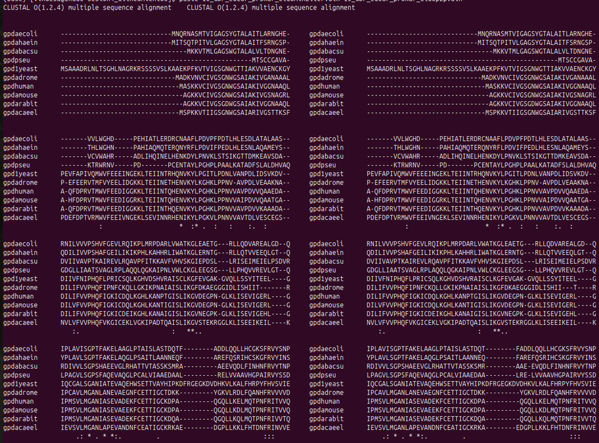

$Clustal\Omega$ p2p vs. iteration alignment of 10_GDP_eucar_prokar sequences with Kimura distances.

As shown above, there are minimal differences in the p2p *vs.* the iteration alignment with *Kimura* (corrected) distances performed on the full set of 10 GDP sequences. Can you spot them?

Based on the high similarity of both $Clustal\Omega$ alignments, we might conclude that the p2p and the full alignment with two iterations are better than the s2p alignment presented in a previous section.

## 5.7 CDS alignment of leuA-Bacillales.fas using $clustalo$

As discussed previously, CDSs should be aligned using their aligned translation products as a guide. Here is how to do it using $clustal\Omega$:

```bash
# 1. Translate the leuA-Bacillales.fas file with the aid of the translate_fastas.pl Perl script
translate_fastas.pl -e fas -t 11

# 2. Remove the trailing *'s resulting from the translation of stop codons present in the DNA sequences
sed 's/\*$//' leuA-Bacillales_translated.faa > k && mv k leuA-Bacillales_translated.faa

# 3. Align the tranlation products keeping the input order
clustalo -i leuA-Bacillales_translated.faa -o leuA-Bacillales_translated_cluo.faa --output-order input-order --threads 4

# 4 Use the prot2cdnAln.pl Perl script to generate the codon alignment using the protein alignment as a guide
prot2cdnAln.pl leuA-Bacillales.fas leuA-Bacillales_translated_cluo.faa
```

### 5.7.1 Visualize the codon alignment with seaview

Finally, we will visualize the resulting codon alignment of the *leuA* CDSs at the DNA and protein levels.

```bash
seaview  leuA-Bacillales_cdnaln.fas &
```

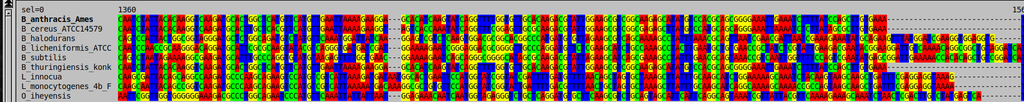

$Clustal\Omega$ codon alignment of leuA CDSs.

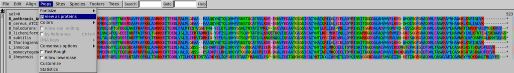

$Clustal\Omega$ codon alignment of leuA CDSs viewed as proteins.

## 5.8 Multiple sequence alignment using an external profile HMM

As previously introduced, a key feature of $Clustal\Omega$ is that it can take an external **profile hidden Markov model** of a protein family, and use it to aid in the alignment highly divergent members.

As mentioned by Sievers & Higgins (2014), the main problem with progressive multiple sequence alignment is that alignments that were made during the early stages of the MSA cannot be changed at a later stage. This has been summarized by the phrase “once a gap, always a gap”. Therefore, it would be very advantageous if the algorithm could be provided with some degree of ‘foresight’ to know in advance which alignment columns are conserved and important in the alignment (Sievers & Higgins, 2014). Some foresight can be communicated to $Clustal\Omega$ in the form of an external, previously contstructed **profile hidden Markov model (profile HMM)** of the protein family to be aligned.

The use of profile HMMs is particularly natural within $Clustal\Omega$, as its main alignment algorithm is based on alignment of profile HMMs (Söding, 2005; Sievers 2011). A profile HMM can be supplied to $Clustal\Omega$ as an ‘external profile’. The alignment of the unaligned residues will be guided by the distribution of residues and gaps in the HMM. Residues of the unaligned sequences will be aligned to the positions within the HMM that best fit the signature, and this is used to align those residues more accurately.

Obviously, the accuracy of the HMM will affect the quality of the HMM-guided MSA. However, experience has shown that external profile HMM information is rarely detrimental (Sievers et al., 2011). Use of HMMs as external profiles is therefore very robust. Its use is most helpful in the alignment of highly diverged sequences with low average pairwise sequence similarity. Such scenarios frequently lead to early misalignment and/or gaps, which can be partly avoided using background information provided by the HMM.

This procedure can be used if an existing multiple alignment of a set of sequences that has been carefully maintained is available. It can then be converted to a HMM and used to help align new sequences. Alternatively, HMMs can be downloaded from alignment databases such as [PFAM](http://pfam.xfam.org/). This procedure is also used to iterate the multiple alignment process, as described in the previous section.

### 5.8.1 Alignment of 146 human Ras GTPases using the PF00071 HMM

As a final exercise, we will align the classic set of 146 human Ras GTPases compiled by [Wennerberg et al. (2005)](https://journals.biologists.com/jcs/article/118/5/843/28805/The-Ras-superfamily-at-a-glance) with the aid of the PFAM00071.hmm model for the Ras superfamily, fetched from [PFAM](http://pfam.xfam.org/). Note that on the chaac server the alignment takes ~5 seconds to complete using 4 cores, which is almost twice the time it takes to align under the default $clustalo$ parameterization, as demonstrated below:

```bash
# default clustalo alignment
time clustalo -i Human_Ras_Superfam_proteins_Wennerberg_JCS05.faa -o Human_Ras_Superfam_proteins_Wennerberg_JCS05_cluo.afa --outfmt fasta --threads 4

# clustalo using the Ras_fam_PF00071.hmm as HMM input
time clustalo -i Human_Ras_Superfam_proteins_Wennerberg_JCS05.faa --hmm-in Ras_fam_PF00071.hmm -o Human_Ras_Superfam_proteins_Wennerberg_JCS05_PF00071.afa --outfmt fasta --threads 4
```

```
# default clustalo alignment
real    0m2.912s
user    0m7.995s
sys 0m0.136s

# clustalo using the Ras_fam_PF00071.hmm as HMM input
real    0m5.032s  <== just ~ 5 seconds with 4 threads
user    0m14.801s
sys 0m0.151s
```

Below you’ll see a screenshot of the central part of the HMM-guided alignment, the region modeled by the PFAM00071 profile, for a fraction of the 146 sequences, and displayed with $seaview$.

```bash
# visualize the PF00071.hmm-assisted alignment
seaview Human_Ras_Superfam_proteins_Wennerberg_JCS05_PF00071.afa &
```

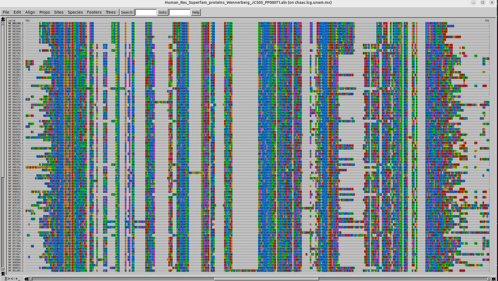

Ras superfamily clustal-omega alignment using PFAM00071 as external profile HMM.

The alignment shown above was used to compute the **maximum likelihood tree for the Ras superfamily** presented below (Vinuesa, unpubl.)

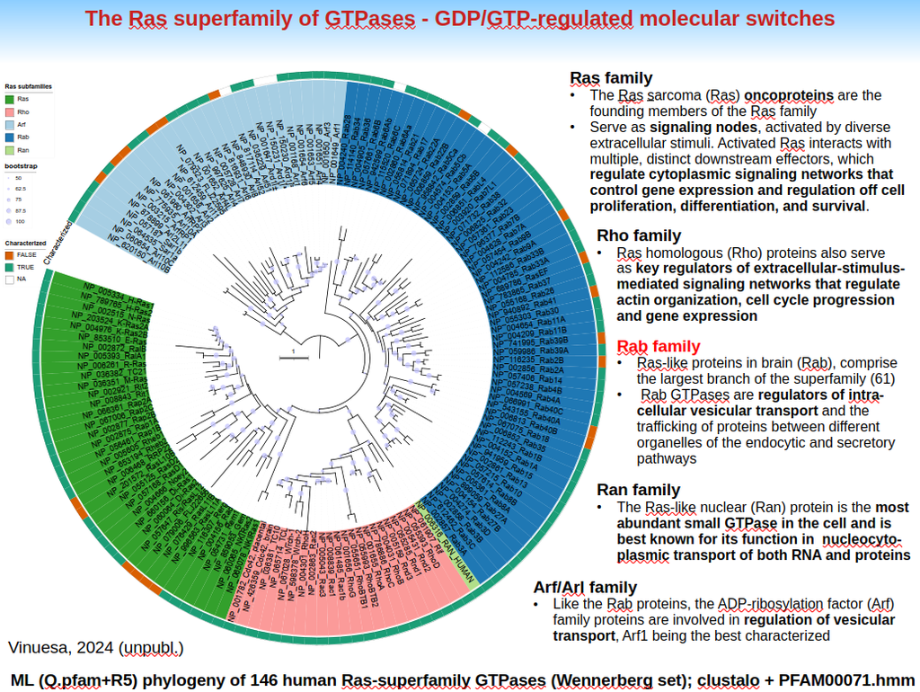

Maximum likelihood phylogeny of 146 human Ras superfamily members. Vinuesa unpubl.

In the HMMER section that follows, we will focus on the **Rab family of small GTPases**, the largest one within the Ras superfamily.

### 5.8.2 Motif and logo analysis of highly conserved alignment regions of the Ras superfamily and their extraction using $seaview$

$Seaview$ can be used to easily extract certain alignment regions or columns under ‘Sites > Create Set > OK’. Then left-click on the white ‘X’ label immediately adjacent to the first conserved alignment column that you would like to keep, followed by a right click on the preceding ‘X’. This will exclude the N-terminal region flanking your region of interest (ROI). Next, move to C-terminal part of your ROI and repeat the left- and right-clicks to exclude the non-desired C-terminal region. Then type `CTRL-A` to select all sequences and save them under ‘Save > Save selection’. Note that you can un-select particular sequences before saving them to disk by left-clicking on their IDs.

The extracted alignment blocks can then be used to **compute sequence logos** and simple profiles that summarize the residue frequency distribution in such blocks using *ad hoc* Perl and R scripts, or Web-servers such as [WebLogo 3](https://weblogo.threeplusone.com/create.cgi).

Below the **logo** and **motif** representations of the first highly conserved (G1) region of Ras GTPases, including non-gaped flanking columns.

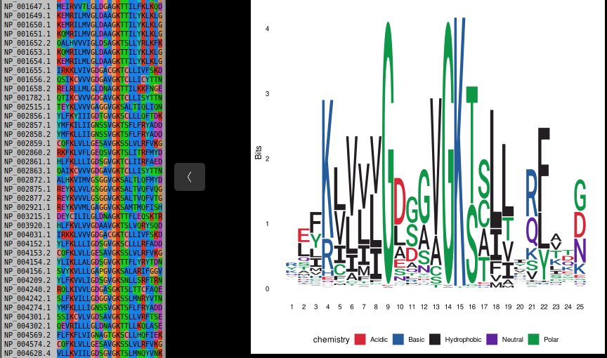

Alignment and sequence logo of the highly conserved G1 signature region of human Ras GTPases.

A simpler, less informative way to represent these highly conserved signatures is by a simple **sequence motif** summarizing the pattern, as shown below:

```
# sequence motif for the highly conserved G1 region of Ras GTPases with max. degeneracy set to 4
xxxxxxxx[GAE]xxxx[GAV][KT][TSGK]xxxxxxxxx
```

## 5.9 Clustal exercise

Perform the following tasks, documenting the commands used, and the results obtained, in a fashion similar to that used in previous sections of this tutorial.

Important note: all $clustalo$ alignments should be run with four threads using option

```
–threads
4
```

### 5.9.1 16S rDNA sequence to profile alignment

1. Get the file 16S_problema.fna used in the BLASTN tutorial, and use the $fasta\_toolkit.awk$ script to determine their sequence lengths.
- Generate a new *16S_problema_len_filt.fna* file containing only sequences >= 450 bp.
- How many sequences are contained the original file? How many are found in 16S_problema_len_filt.fna?
2. Use $Clustal\Omega$ in sequence-to-profile alignment mode to align the 16S_problema_len_filt.fna sequences to the 16S_reference_profile.fst profile, which you can find on chaac here: /export/space3/users/vinuesa/DBs/profiles

### 5.9.2 Alignment of *rpoB* CDS sequences from *Enterobacteriaceae*

3. Explore and optimize the FASTA header (reducing redundancy, for optimal information content) for the rpoB_enterics.fasta file, which you can get from /export/space3/users/vinuesa/DBs/sequences on chaac.
4. translate the sequences and align them at the protein level
5. Make a [codon alignment]#(CDS_alignment) using the helper scripts provided in this tutorial for this task.

### 5.9.3 Finding highly conserved motifs in Ras GTPases and their representation as sequence logos

1. Read the Wennenberger et al. 2015 short review paper on the Ras GTPase superfamily [J Cell Sci. 2005 Mar 1;118(Pt 5):843-6. doi:10.1242/jcs.01660.](https://journals.biologists.com/jcs/article/118/5/843/28805/The-Ras-superfamily-at-a-glance).
- What is the functional role of the conserved G motifs of Ras GTPases?
- Use $seaview$ to explore the two alignments that we generated for the Human_Ras_Superfam_proteins_Wennerberg_JCS05.faa set, locate the five G motifs described in the paper, and extract them as ‘regions’ along with any non-gaped columns flanking them, saving each of these regions to a file.
- Use the [WebLogo app](https://weblogo.threeplusone.com/create.cgi) to create sequence logos for each of the five G motifs and non-gaped flanking columns. Compile all five logos into a single image, properly label each panel, provide a short but informative description, and save the final figure in PDF format.

# 6 Profile hidden Markov models, and HMMER3

**Pairwise sequence comparison methods such as BLASTP and FASTA assume that all amino acid positions are equally important**. However, it is well known that different residues in a functional sequence are subject to varying selective pressures.

We have clearly observed these patterns of variable conservation across columns in the multiple sequence alignments that we have computed. Some positions are more conserved than others, and some regions seem to tolerate insertions and deletions more than other regions.

Therefore, it would be **desirable to use position-specific information from multiple alignments** when searching databases for homologous sequences, or aligning highly divergent sequences.

**Profile HMMs** turn a multiple sequence alignment into a **position-specific scoring system** suitable for searching databases for remotely homologous sequences [Eddy, (1998)](https://doi.org/10.1093/bioinformatics/14.9.755), and guiding the calculation of MSAs. Profile HMMs integrate the positions-specific scores for each amino acid along with its insertion and deletion scores, and transition scores between the **match** (M1-MX), **insertion** (I0-IX) and **deletion** (D1-DX) **states**, as summarized in the Figure shown below:

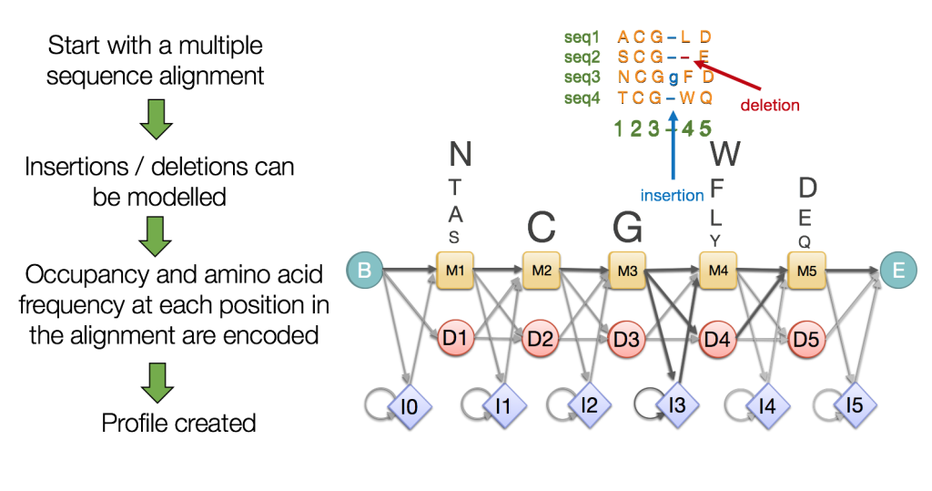

Steps for **converting a MSA into a profile hidden Markov model**.(https://www.ebi.ac.uk/training/online/courses/pfam-creating-protein-families/what-are-profile-hidden-markov-models-hmms/ ).

[**HMMER**](http://hmmer.org/) is a software package that implements many programs to build and use **profile hidden Markov models (profile HMMs)** for different bioinformatic tasks, including searching sequence databases for remote sequence homologs, aligning multiple sequences, and scanning a sequence for the presence of certain domains modeled as HMMs [(Eddy, 2011)](https://journals.plos.org/ploscompbiol/article?id=10.1371/journal.pcbi.1002195).

[figure not shown]

hmmer.org

## 6.1 HMMER3 tutorial overview

The [HMMER v3.4](http://hmmer.org/) package contains 18 programs, plus a set of auxiliary tools.

The programs $hmmbuild$, $hmmsearch$, $hmmscan$, and $hmmalign$ provide the core functionality for protein domain analysis and annotation pipelines, for instance using profile databases like [Pfam](http://pfam.xfam.org/).

This tutorial will focus on these four programs, used for the the following tasks:

- Compute a **profile HMM** using $hmmbuild$ from a given reference (seed) alignment
  - Calibrate the new HMM using [Swiss-Prot proteins](https://www.expasy.org/resources/uniprotkb-swiss-prot) to determine a suitable **score cutoff**
- Find Rab homologs in the *Acanthamoeba castellanii* proteome using $hmmsearch$ with the cutoff scores determined during the calibration phase
- Extract the $hmmsearch$ hits and align them to a reference profile HMM using $hmmalign$
- Given a query protein, interrogate a HMM library using $hmmscan$ to determine/annotate the domain composition of the protein

## 6.2 Preliminaries: preparing the working directory

Save the following paths in variables for easy access to the sequences and databases required for running the exercises on the **chaac server**.

Navigate into the sesion3_clustal_y_hmmer directory, and from therein execute the following lines of code:

```bash
# 1. Change dir into your desired location on chaac and make a new directory for this exercise
# i) Change directory into your working directory and make the following new directory to hold the sequence data for the exercises
if [ ! -d HMMER ]; then
    mkdir HMMER && cd HMMER
else
   cd HMMER
fi

# 2. save the following paths in variables for easy access to the sequences and databases
base_dir=/export/space3/users/vinuesa/DBs
sp_db="${base_dir}"/Swiss-Prot
pfam_db="${base_dir}"/Pfam
euk_proteomes="${base_dir}"/euk_proteomes
sequences="${base_dir}"/sequences

# make symlinks from your working directory to the sequence data to avoid copying large files
ln -s  $euk_proteomes/*faa .
ln -s $sequences/Rab_SPhyd94.faa .
```

## 6.3 Build a Rab family-specific HMM, calibrate the model using swiss-prot reference proteins, and find all small Rab GTPases encoded in the *Acanthamoeba castellanii* proteome

This exercise will focus on **Rab GTPases** from the free-living amoeba *Acanthamoeba castellanii* ([Rivera et al. 2024](https://journals.asm.org/doi/10.1128/spectrum.02988-23)), the largest family within the superfamily of **Ras GTPases** ([Wennenberger et al. 2005](https://journals.biologists.com/jcs/article/118/5/843/28805/The-Ras-superfamily-at-a-glance)) presented in an earlier section.

The goal is to **construct a Rab GTPase-specific HMM**, and calibrate the model to identify all *bona fide* Rab GTPase homologs in a given proteome with high specificity and sensitivity.

This exercise will guide you through some of the basic steps commonly performed to generate a custom HMM to search for homologs, which typically involve:

1. Computing an alignment from a collection of *bona fide* homologs representative of the evolutionary diversity of your target family (seed sequences), in this case Rab GTPases from human, yeast, and *Dictyostelium*
2. Building an HMM from the **seed alignment** using $hmmbuild$
3. Searching a database of curated sequences like [Swiss-Prot](https://www.expasy.org/resources/uniprotkb-swiss-prot) with $hmmsearch$ to define a suitable **score cutoff value**
4. Searching the proteome(s) of your interest with $hmmsearch$, using the previously defined cutoff value to select *bona fide* hits
5. Extracting the hit sequences for further downstream analyses
6. Adding the new homologs to the collection of seed sequences, and constructing a new HMM based on the **full alignment**

### 6.3.1 What are Rab GTPases

Rab proteins constitute the largest family within the Ras superfamily, as shown previously on the tree of the Ras superfamily, with approximately 70 members identified in humans. Rab GTPases are the primary regulators of the vesicular trafficking pathways involved in transporting the vast array of cellular cargo across membrane organelles [(Stenmark, 2009)](https://www.nature.com/articles/nrm2728). The Rabs function as molecular switches in regulating the formation, transport, docking, and fusion of transport vesicles during membrane transport, being active when bound with GTP. In order to be able to associate with organellar membranes, Rabs get prenylated (lipidated) at their C-termini. Below a scheme depicting the cellular locations of specific Rabs.

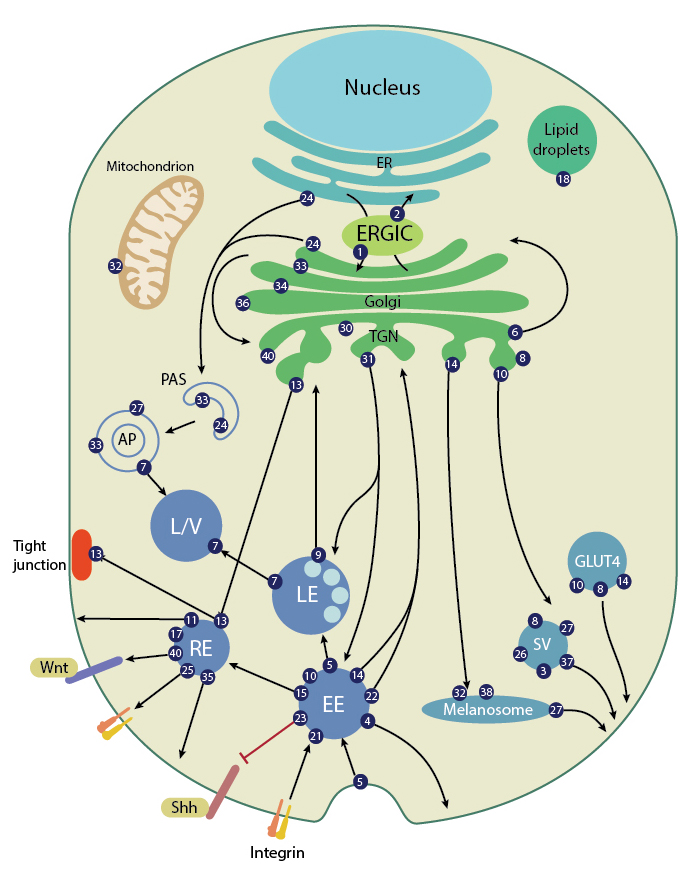

Rab GTPases as regulator of intracellular membrane trafficking; https://www.mbi.nus.edu.sg/mbinfo/what-are-rab-gtpases/

### 6.3.2 Align 94 bona-fide Rab GTPases from human, yeast and dicty

The Rab_SPhyd94.faa FASTA file contains [Swiss-Prot](https://www.expasy.org/resources/uniprotkb-swiss-prot) entries for *bona fide* Rab GTPases from human, yeast and *Dictyostelium*.

Before proceeding with the alignment, let us get some notion about the sequences in the Rab_SPhyd94.faa FASTA file by obtaining the following information:

#### 6.3.2.1 Sequence length distribution of proteins in the Rab_SPhyd94.faa FASTA file

We will obtain the following information: - Number of sequences in the file - Summary statistics of sequence lengths

```bash
# Number of sequences in the file
grep -c '^>' Rab_SPhyd94.faa

echo '=='

# Summary statistics of sequence lengths; Note requires fasta_toolkit.awk v0.6
fasta_toolkit.awk -R 6 Rab_SPhyd94.faa | cut -f2 | col_sumStats.sh
```

```
94
==
Min: 194
Mean: 220.457
Median: 213.5
Mode: 201,203
Max: 417
```

As summarized above, and confirmed by the histogram shown below, most **canonical Rab GTPases are between 200 and 250 amino acids long**.

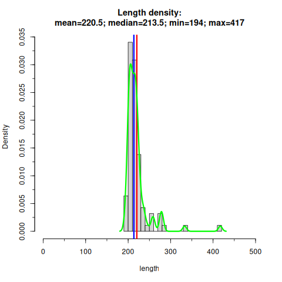

Histogram for sequence lengths of 94 canonical Rab GTPases stored in Rab_SPhyd94.faa

```bash
# R code to plot the length histogram with summary statistics shown below
# https://rdrr.io/cran/Hmisc/man/Overview.html
options(Hverbose=FALSE)
library(Hmisc)

# read data
dfr <- read.table(file="Rab_SPhyd94_lengths.tsv", header = FALSE, sep = "\t")

# explore the structure of the object dfr
str(dfr)

# compute summary statistics
max_len=max(dfr$V2)
min_len=min(dfr$V2)
max_len_extended=max_len+(max_len*0.2)
avg <- round(mean(dfr$V2),1)
med <- round(median(dfr$V2),1)

# plot using the base system
titl=paste0("Length density:\nmean=", avg, "; median=", med, "; min=", min_len, "; max=", max_len)
hist(dfr$V2, breaks = "Freedman-Diaconis", xlim = c(0, max_len_extended), probability=TRUE, xlab="length", main=titl)
minor.tick(nx=2, tick.ratio=0.5) # from Hmisc package
abline(v = median(dfr$V2), col = "blue", lwd = 3)
abline(v = mean(dfr$V2), col = "red", lwd = 3)
lines(density(dfr$V2), col = 'green', lwd = 3)
```

#### 6.3.2.2 Confirmation that the reference Rab sequences contain at least one cysteine among the five C-terminar residues, required as prenylation sites

As a final check of our reference Rab GTPases, let us extract the final five C-terminal residues of each sequence to verify that this region contains at least one **cysteine** residue, used as **prenylation (lipidation) site**, required by Rab proteins to insert into the membranes of the vesicles that they associate with to control their intracellular trafficking.

We will make use of the *ad hoc* Perl script `extract_N-or_C-terminal_regions_and_compute_counts.pl` designed for this task. The script will extract the indicated number of C-terminal residues, count the instances of a user-specified amino acid in this region, and compute its over-all amino acid frequencies.

```bash
# print the script's help
extract_N-or_C-terminal_regions_and_compute_counts.pl
```

```
Usage for extract_N-or_C-terminal_regions_and_compute_counts.pl v0.1_2024-11-01:

extract_N-or_C-terminal_regions_and_compute_counts.pl --fasta  --output  --residues  --region  --count_residue

Options:
    --fasta|-f          Input multi-FASTA file of protein sequences
    --output|-o         Output file prefix (for generated FASTA and tabular files)
    --residues|-n       Number of N-terminal or C-terminal residues to extract
    --region|-r         Region to extract: 'N' for N-terminal or 'C' for C-terminal
    --count_residue|-a  Residue to count in the extracted region (e.g., M for methionine, C for cysteine)
    --help              Show this help message

AIM:
   Extracts a specified number of N- or C-terminal residues from each protein sequence in a multi-FASTA file,
     computes basic overall residue frequencies in the extracted region, and counts instances of a focal amino acid.
   This is useful, for example, to verify and analyze the distribution of cysteines found among
     the five C-terminal residues of Rab GTPases

OUTPUT:
    multi-FASTA with the extracted N- or C-terminal regions
    Three-col table with the seq_id, sequence, counts for user-defined residue in the extracted sequence
    Matrix with overall proportions of each amino acid at each site of the extracted sequences
```

```bash
# Extract the five C-terminal residues of each sequence, and count the number of cysteines (C's) in that region
extract_N-or_C-terminal_regions_and_compute_counts.pl -f Rab_SPhyd94.faa -o Rab_SPhyd94_5CtCs -n 5 -r C -a C

# explore the header of the resulting Rab_SPhyd94_5CtCs_Cterm.tsv file
cat Rab_SPhyd94_5CtCs_Cterm.tsv | head -5

# print any sequences do not have at least one C among its five terminal residues on its C-terminus
awk -F "\t" '$3 == 0' Rab_SPhyd94_5CtCs_Cterm.tsv
```

```
sp|P51159|RB27A_HUMAN   GACGC   2
sp|Q9H082|RB33B_HUMAN   MTCWC   2
sp|P20336|RAB3A_HUMAN   QDCAC   2
sp|P20337|RAB3B_HUMAN   QNCSC   2
sp|Q96E17|RAB3C_HUMAN   PNCAC   2
```

As expected, all sequences have at least one cysteine among their five C-terminal residues.

#### 6.3.2.3 Computing a **multiple sequence alignment** of the Rab reference sequences using $clustal\Omega$.

After having verified that we have *bona fide* Rab GTPases in our FASTA file, let us align the sequences using $clustal\Omega$ with the following command:

```bash
clustalo -i Rab_SPhyd94.faa -o Rab_SPhyd94_cluoAln.afa --iter 2 --use-kimura --threads 4
```

### 6.3.3 Build the profile HMM with $hmmbuild$

We will use the multiple sequence alignment of reference Rab GTPases computed in the previous step to build a **profile HMM** from this **seed alignment** with $hmmbuild$. The following line generates the **Rab.hmm profile hidden Markov model** from the input alignment Rab_SPhyd94_cluoAln.afa

```bash
hmmbuild -h
# hmmbuild :: profile HMM construction from multiple sequence alignments
# HMMER 3.4 (Aug 2023); http://hmmer.org/
# Copyright (C) 2023 Howard Hughes Medical Institute.
# Freely distributed under the BSD open source license.
# - - - - - - - - - - - - - - - - - - - - - - - - - - - - - - - - - - - -
# Usage: hmmbuild [-options] <hmmfile_out> <msafile>
# ... truncated
hmmbuild Rab.hmm Rab_SPhyd94_cluoAln.afa
```

#### 6.3.3.1 Exploring HMMER’s profile model files

Let us inspect the Rab.hmm file generated by $hmmbuild$:

```bash
head -25 Rab.hmm
```

```
HMMER3/f [3.4 | Aug 2023]
NAME  Rab_SPhyd94_cluoAln
LENG  344
ALPH  amino
RF    no
MM    no
CONS  yes
CS    no
MAP   yes
DATE  Sun Oct 27 18:43:28 2024
NSEQ  94
EFFN  3.892761
CKSUM 2257599252
STATS LOCAL MSV      -11.4380  0.70024
STATS LOCAL VITERBI  -12.1821  0.70024
STATS LOCAL FORWARD   -5.3353  0.70024
HMM          A        C        D        E        F        G        H        I        K        L        M        N        P        Q        R        S        T        V        W        Y
            m->m     m->i     m->d     i->m     i->i     d->m     d->d
  COMPO   2.50654  4.17120  2.93335  2.68440  3.33488  2.88766  3.80488  2.86641  2.56945  2.55827  3.70354  3.03682  3.48961  3.03847  2.92385  2.53989  2.73769  2.67286  4.52173  3.54948
          2.68618  4.42225  2.77520  2.73124  3.46354  2.40513  3.72495  3.29354  2.67741  2.69355  4.24649  2.90347  2.73740  3.18147  2.89801  2.37887  2.77520  2.98519  4.58477  3.61503
          0.10610  2.44147  4.29506  0.48460  0.95697  0.00000        *
      1   2.72646  4.32781  3.85243  3.37720  3.17928  3.69271  4.20027  2.11813  3.17844  1.78667  2.53735  3.68219  4.14144  3.55450  3.43575  3.07210  3.02843  1.90272  5.00825  3.74883      2 l - - -
          2.68618  4.42225  2.77519  2.73123  3.46354  2.40513  3.72494  3.29354  2.67741  2.69355  4.24690  2.90347  2.73739  3.18146  2.89801  2.37887  2.77519  2.98518  4.58477  3.61503
          0.04261  3.57272  4.29506  0.61958  0.77255  0.48576  0.95510
      2   2.36474  4.18722  3.26296  2.91549  3.49111  3.14356  3.88857  2.38634  2.80576  2.55101  3.61050  3.21077  3.75399  3.21637  3.09572  2.16970  2.74516  2.43597  5.02404  3.68037      3 s - - -
          2.68618  4.42225  2.77519  2.73123  3.46354  2.40513  3.72494  3.29354  2.67741  2.69355  4.24690  2.90347  2.73739  3.18146  2.89801  2.37887  2.77519  2.98518  4.58477  3.61503
          0.04261  3.57272  4.29506  0.61958  0.77255  0.48576  0.95510
... truncated
    343   2.81986  4.34111  3.91257  3.53906  3.21715  3.73397  4.32616  1.48544  3.35834  1.89221  3.22770  3.81877  4.21260  3.74827  3.58392  3.22433  3.13444  1.91249  5.03377  3.73193    609 i - - -
          2.68618  4.42225  2.77519  2.73123  3.46354  2.40513  3.72494  3.29354  2.67741  2.69355  4.24690  2.90347  2.73739  3.18146  2.89801  2.37887  2.77519  2.98518  4.58477  3.61503
          0.04086  3.61383  4.33618  0.61958  0.77255  0.58636  0.81272
    344   2.22260  4.12679  3.00636  2.82925  3.81081  2.86240  3.93575  3.30649  2.88075  3.05674  4.02473  3.08679  3.58300  3.25901  3.16161  1.57168  2.68606  2.90530  5.21115  3.89650    610 s - - -
          2.68618  4.42225  2.77519  2.73123  3.46354  2.40513  3.72494  3.29354  2.67741  2.69355  4.24690  2.90347  2.73739  3.18146  2.89801  2.37887  2.77519  2.98518  4.58477  3.61503
          0.02769  3.60066        *  0.61958  0.77255  0.00000        *
//
```

Each profile HMM file starts with a format version identifier (here, HMMER3/f), and ends with // on a line by itself, which allows multiple profiles to be concatenated.

The format is divided into two regions: 1. The first region contains textual information and miscellaneous parameters in a roughly tag-value scheme. This section ends with a line beginning with the key-word HMM. 2. The second region is a tabular, white space-limited format for the main model parameters.

**All probability parameters are all stored as negative natural log probabilities** with five digits of precision to the right of the decimal point, rounded. For example, a probability of 0.25 is stored as −log 0.25 = 1.38629. The special case of a zero probability is stored as ’*’.

**Main model section**

The first two lines in the main model section are atypical. They contain information for the core model’s BEGIN node.

The remainder of the model has three lines per node, for **M nodes** (where M is the number of match states, as given by the LENG line). These three lines are (K is the alphabet size in residues): * **Match emission** line * **Insert emission** line * **State transition** line, where m = match, d = delete, i = insert.

Finally, the last line of the format is the “//” record separator.

For the details, consult the [HMMER3.4 User guide](http://hmmer.org/documentation.html).